# QMM1002 Case Study 1

Himanshu Bairagi

A00263144

Due: February 24, 2023 at 11:59PM

## Introduction

Time management is one of the most critical aspects of a student’s life. Efficiently managing classes, studies, and physical and mental health is significant for all-rounded success. This case study aims to understand certain essential aspects of everyday life by collecting and analyzing different data points over time. At the conclusion of this study, we should be able to provide answers to three key questions. Am I meeting the planned study goals? Am I maintaining a healthy routine? Do I get enough quality sleep?

The data points for this study are a combination of quantitative and categorical characteristics, and they are chosen from two key segments: studies and health. Variables such as time spent in Zoom lectures and time spent studying can help us determine whether we are achieving our academic goals. On the other hand, factors like step count and sleep quality can aid in understanding the general quality of health and life. Below is a list of all eight variables.

News watched (yes/no), workouts (yes/no), and sleep quality (poor, fair, good, excellent) are the categorical factors. The quantitative factors are cups of coffee consumed (number of cups), the amount of time spent on Zoom meetings (time in hours), the amount of time spent studying (time in hours), the amount of time spent sleeping (time in minutes), and the steps count (number of steps). In this study, only the data from September 12, 2022, to February 12, 2023, are used. The dataset’s level of granularity is day level.

**Variables collected:**

| Variable | Type |
| --- | --- |
| Date | Identifier |
| Zoom Hours | Quantitative |
| Study Hours | Quantitative |
| Sleep Minutes | Quantitative |
| Cups of Coffee | Quantitative |
| Watch the News | Categorical |
| Workout | Categorical |
| Sleep Quality (Poor, Fair, Good, Excellent) | Categorical |
| Step Count | Quantitative |

The variables that will be analyzed are hours spent studying, minutes spent sleeping, and steps count.

**Summary statistics of the three variables to be analyzed:**

```r
# set working directory
setwd("D:/Business Analytics Program/Winter Term/QMM1002 - Stats and Data Visualization/3. Assignments/")

# read necessary data sets
pd<-read.csv(file='Case Study 1/Bairagi, Himanshu Personalized Data.csv', header=TRUE)

# subset the data
pd.3vars<-subset(pd, select=c("Study_hours", "Sleep_minutes", "Step_Count"))

# summarize the three variables to be analyzed
summary(pd.3vars)
```

```
##   Study_hours    Sleep_minutes     Step_Count
##  Min.   :0.000   Min.   :236.0   Min.   : 1315
##  1st Qu.:3.000   1st Qu.:377.0   1st Qu.: 3290
##  Median :4.000   Median :417.0   Median : 5716
##  Mean   :4.013   Mean   :416.6   Mean   : 6562
##  3rd Qu.:6.000   3rd Qu.:459.8   3rd Qu.: 8544
##  Max.   :8.000   Max.   :570.0   Max.   :20296
```

**Check conditions and assumptions of t-distribution:**

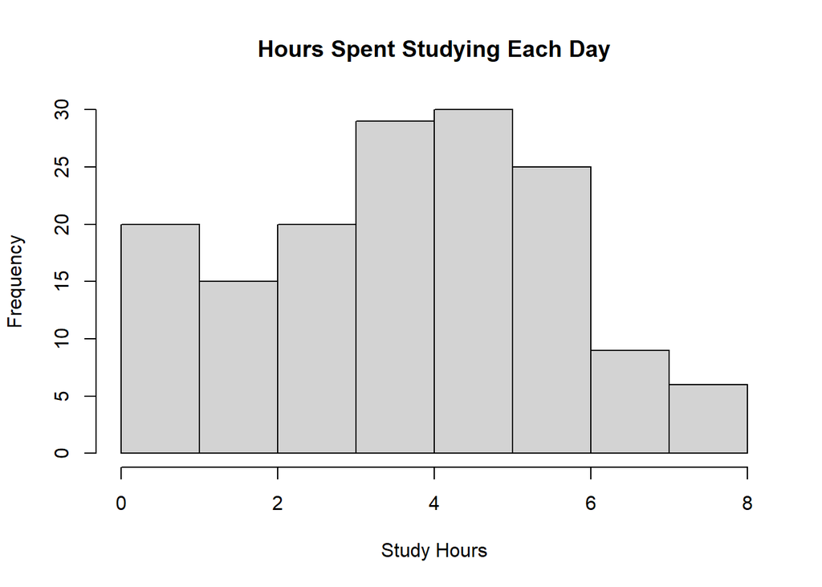

[figure not shown]

- Sleep Minutes: The distribution of minutes slept is fairly normal. The data has low variance as highlighted by the box plot, and a solitary outlier.

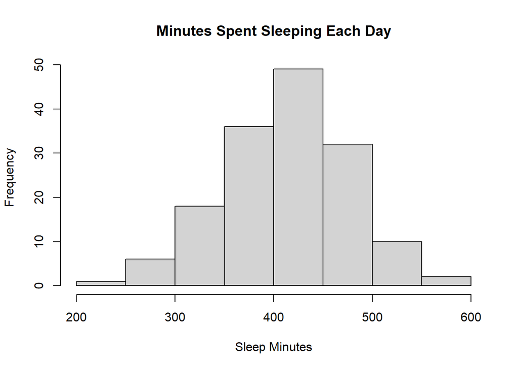

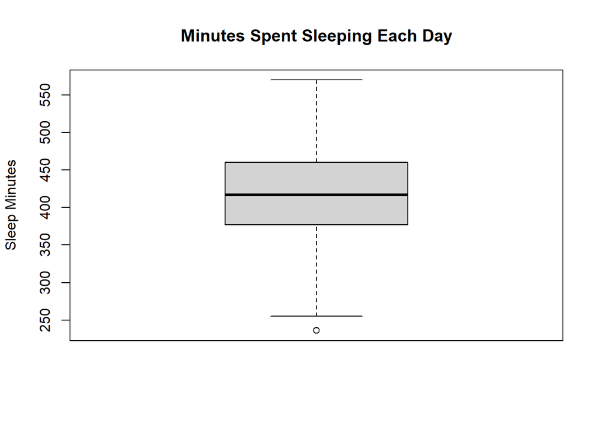

- Steps Count: The steps count data is non-normal, and is skewed on the right tail. The data also has considerable variance and outliers.

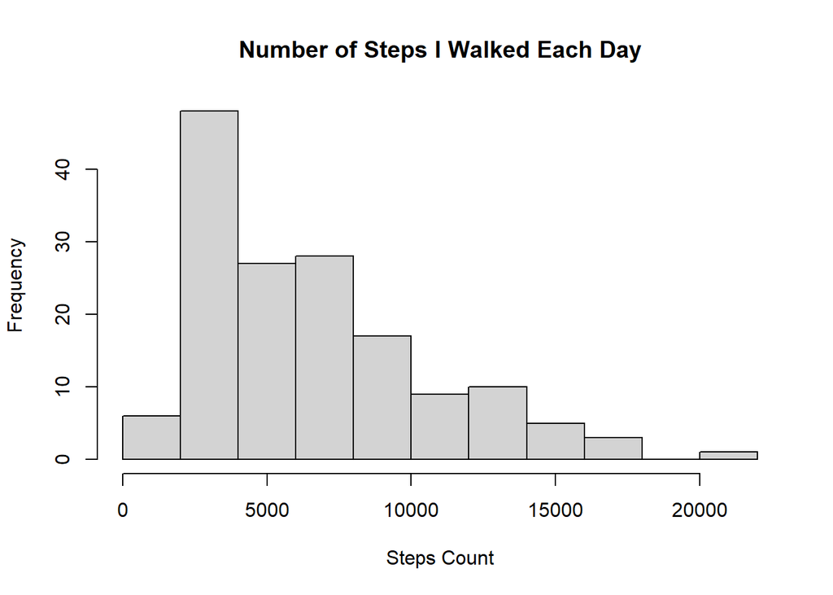

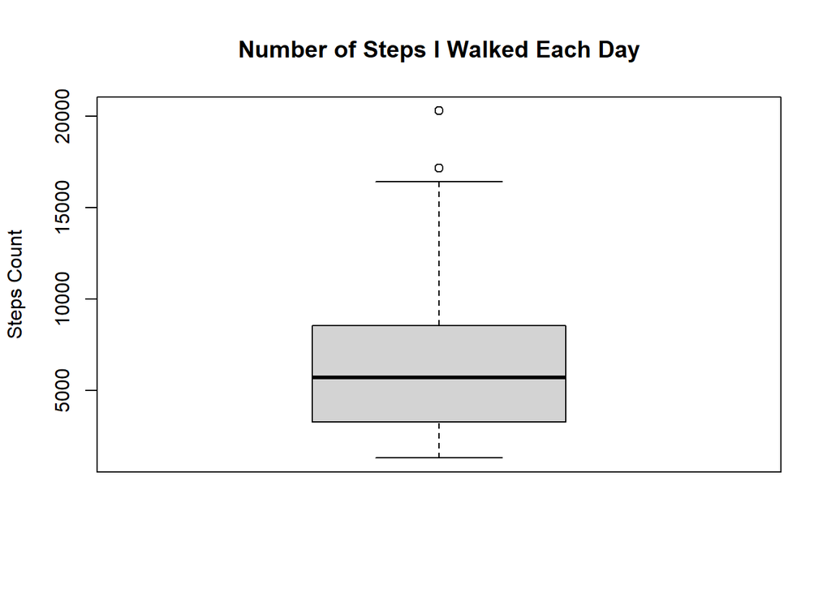

## Analysis

### Part 1: Confidence Intervals

**1. 95% confidence interval for the mean number of hours spent studying per day:**

```r
# sample size
pd_stud_n <- length(pd$Study_hours) # pd_stud_n = 154

# mean hours spent studying
pd_stud_mean <- mean(pd$Study_hours) # pd_stud_mean = 4.012987

# standard deviation
pd_stud_sd <- sd(pd$Study_hours) # pd_stud_sd = 2.138923

# standard error
pd_stud_se <- pd_stud_sd/sqrt(pd_stud_n) # pd_stud_se = 0.1723594

# t-critical at 95%
pd_stud_t_crit <- qt(0.95/2+0.5, df=pd_stud_n-1) # pd_stud_t_crit = 1.97559

# margin of error
pd_stud_me <- pd_stud_se*pd_stud_t_crit # pd_stud_me = 0.3405115

# confidence interval at 95%
pd_stud_ci <- pd_stud_mean + c(-pd_stud_me, pd_stud_me) # pd_stud_ci = (3.672476 - 4.353499)
```

**Inference:** I wanted to devote five hours a day to studying and assignments, but it is clear that I’m unable to devote that much time at this point.

……………………………………………………………………………………………………………………………………………………………………………

**2. 95% confidence interval for the mean number of hours spent sleeping per day:**

```r
# sample size
pd_slp_n <- length(pd$Sleep_minutes) # pd_slp_n = 154

# mean hours spent studying
pd_slp_mean <- mean(pd$Sleep_minutes) # pd_slp_mean = 416.6299

# standard deviation
pd_slp_sd <- sd(pd$Sleep_minutes) # pd_slp_sd = 63.78712

# standard error
pd_slp_se <- pd_slp_sd/sqrt(pd_slp_n) # pd_slp_se = 5.140113

# t-critical at 95%
pd_slp_t_crit <- qt(0.95/2+0.5, df=pd_slp_n-1) # pd_slp_t_crit = 1.97559

# margin of error
pd_slp_me <- pd_slp_se*pd_slp_t_crit # pd_slp_me = 10.15476

# confidence interval at 95%
pd_slp_ci <- pd_slp_mean + c(-pd_slp_me, pd_slp_me) # pd_slp_ci = (406.4751 - 426.7846)
```

**Inference:** My objective of getting seven hours of sleep per day is being quite closely met, according to the analysis of my sleep minutes.

……………………………………………………………………………………………………………………………………………………………………………

**3. 95% confidence interval for the mean of number of steps walked per day:**

```r
# sample size
pd_step_n <- length(pd$Step_Count) # pd_step_n = 154

# mean hours spent studying
pd_step_mean <- mean(pd$Step_Count) # pd_step_mean = 6562.422

# standard deviation
pd_step_sd <- sd(pd$Step_Count) # pd_step_sd = 3978.797

# standard error
pd_step_se <- pd_step_sd/sqrt(pd_step_n) # pd_step_se = 320.6206

# t-critical at 95%
pd_step_t_crit <- qt(0.95/2+0.5, df=pd_step_n-1) # pd_step_t_crit = 1.97559

# margin of error
pd_step_me <- pd_step_se*pd_step_t_crit # pd_step_me = 633.415

# confidence interval at 95%
pd_step_ci <- pd_step_mean + c(-pd_step_me, pd_step_me) # pd_step_ci = (5929.007 - 7195.837)
```

### Part 2: One-Sample Hypothesis Tests

**1. Do I spend more hours studying per day than an average McGill University student (3.13 hours)?**

Hypothesis:

$H_0: \mu = 3.13$

$H_A: \mu > 3.13$

```r
# sample size
n_study <- length(pd$Study_hours) # n_study = 154

# t-statistic
t.test(pd$Study_hours, mu=3.13, alternative = "greater")
```

```
##
##  One Sample t-test
##
## data:  pd$Study_hours
## t = 5.1229, df = 153, p-value = 4.47e-07
## alternative hypothesis: true mean is greater than 3.13
## 95 percent confidence interval:
##  3.727754      Inf
## sample estimates:
## mean of x
##  4.012987
```

```r
# t-critical
qt(0.05, df = n_study-1) # t_crit = -1.654874
```

```
## [1] -1.654874
```

Since,

- p-value = 4.47e-07 < 0.05 (alpha)
- t-statistic = 5.1229 > 1.654874 (t-critical)

**Decision:** We reject the null hypothesis.

**Inference:** There is evidence that the mean hours I studied everyday are more than an average McGill University student.

……………………………………………………………………………………………………………………………………………………………………………

**2. Am I getting seven hours of sleep daily?**

Hypothesis:

$H_0: \mu = 7$

$H_A: \mu \neq 7$

```r
# sample size
n_sleep <- length(pd$Sleep_minutes) # n_sleep = 154

# t-statistic
t.test(pd$Sleep_minutes, mu=7, alternative = "two.sided")
```

```
##
##  One Sample t-test
##
## data:  pd$Sleep_minutes
## t = 79.693, df = 153, p-value < 2.2e-16
## alternative hypothesis: true mean is not equal to 7
## 95 percent confidence interval:
##  406.4751 426.7846
## sample estimates:
## mean of x
##  416.6299
```

```r
# t-critical
qt(0.05, df = n_sleep-1) # t_crit = -1.654874
```

```
## [1] -1.654874
```

Since,

……………………………………………………………………………………………………………………………………………………………………………

**3. Am I walking more than 6000 steps per day?**

Hypothesis:

$H_0: \mu = 6000$

$H_A: \mu > 6000$

```r
# sample size
n_step <- length(pd$Step_Count) # n_step = 154

# t-statistic
t.test(pd$Step_Count, mu=6000, alternative = "greater")
```

```
##
##  One Sample t-test
##
## data:  pd$Step_Count
## t = 1.7542, df = 153, p-value = 0.0407
## alternative hypothesis: true mean is greater than 6000
## 95 percent confidence interval:
##  6031.835      Inf
## sample estimates:
## mean of x
##  6562.422
```

```r
# t-critical
qt(0.05, df = n_step-1) # t_crit = -1.654874
```

```
## [1] -1.654874
```

Since,

- p-value = 0.0407 < 0.05 (alpha)
- t-statistic = 1.7542 > 1.654874 (t-critical)

**Decision:** We reject the null hypothesis.

**Inference:** There is evidence that on an average I walk more than 6000 steps a day.

### Part 3: Two-Sample Hypothesis Tests

```r
# first semester
F22 <-subset(pd, Semester=="Fall", select=Study_hours)

# second semester
W23 <-subset(pd, Semester=="Winter", select=Study_hours)
```

……………………………………………………………………………………………………………………………………………………………………………

**2. Did I spend more time studying each day in Semester 1 than in Semester 2?**

```r
# set random state
set.seed(10)

# sample 10 random indexes from F22
F22_rand_index <- sample(1:nrow(F22), 10)

# extract rows corresponding to the random indexes
F22_rand_samp <- F22[F22_rand_index, ]

# sample 10 random indexes from W23
W23_rand_index <- sample(1:nrow(W23), 10)

# extract rows corresponding to the random indexes
W23_rand_samp <- W23[W23_rand_index, ]
```

Hypothesis: I spent more time studying per day during semester 1 than semester 2

$H_0: \mu_f22 - \mu_w23 = 0$

$H_A: \mu_f22 - \mu_w23 > 0$

Method: Paired t-test

Reason: Since we are comparing the study hours of the same individual across two different time periods the data captured would be paired. Additionally, the variance of the two data samples is not same, thus ruling out the pooled t-test.

```r
# t-test
t.test(F22_rand_samp, W23_rand_samp,
       var.equal = FALSE,
       mu = 0,
       paired = TRUE,
       conf.level = 0.95, # alpha = 0.05
       alternative = "greater")
```

```
##
##  Paired t-test
##
## data:  F22_rand_samp and W23_rand_samp
## t = 1.6501, df = 9, p-value = 0.06666
## alternative hypothesis: true mean difference is greater than 0
## 95 percent confidence interval:
##  -0.1331268        Inf
## sample estimates:
## mean difference
##             1.2
```

```r
# critical t value at 95%
qt(0.05, 9, lower.tail=FALSE) # 1.833113
```

```
## [1] 1.833113
```

Since,

- p-value = 0.06666 > 0.05 (alpha)
- t-statistic = 1.6501 < 1.833113 (t-critical)

**Decision:** We fail to reject the null hypothesis.

**Inference:** There is no evidence that I studied more per day in Semester 1 as compared to Semester 2, based on the ten randomly sampled days from the personalized dataset.

……………………………………………………………………………………………………………………………………………………………………………

**3. In the first ten days of each semester, did I spend more time studying each day in Semester 1 than in Semester 2?**

```r
# extract first ten rows from fall semester
F22_f10_samp <- F22[c(1:10), ]

# extract first ten rows from winter semester
W23_f10_samp <- W23[c(1:10), ]
```

Hypothesis: I spent more time studying per day in the first ten days of semester 1 than semester 2

$H_0: \mu_f22 - \mu_w23 = 0$

$H_A: \mu_f22 - \mu_w23 > 0$

Method: Paired t-test

Reason: Since we are comparing the study hours of the same individual across two different time periods the data captured would be paired. Additionally, the variance of the two data samples is not same, thus ruling out the pooled t-test.

```r
# t-test
t.test(F22_f10_samp, W23_f10_samp,
       var.equal = FALSE,
       mu = 0,
       paired = TRUE,
       conf.level = 0.95, # alpha = 0.05
       alternative = "greater")
```

```
##
##  Paired t-test
##
## data:  F22_f10_samp and W23_f10_samp
## t = 1.964, df = 9, p-value = 0.04056
## alternative hypothesis: true mean difference is greater than 0
## 95 percent confidence interval:
##  0.0799495       Inf
## sample estimates:
## mean difference
##             1.2
```

```r
# critical t value at 95%
qt(0.05, 9, lower.tail=FALSE) # 1.833113
```

```
## [1] 1.833113
```

Since,

- p-value = 0.04056 < 0.05 (alpha)
- t-statistic = 1.964 > 1.833113 (t-critical)

**Decision:** We reject the null hypothesis.

**Inference:** There is evidence that I studied more per day in the first ten days of Semester 1 as compared to Semester 2.